# Renewable Water Resources in Eastern Africa

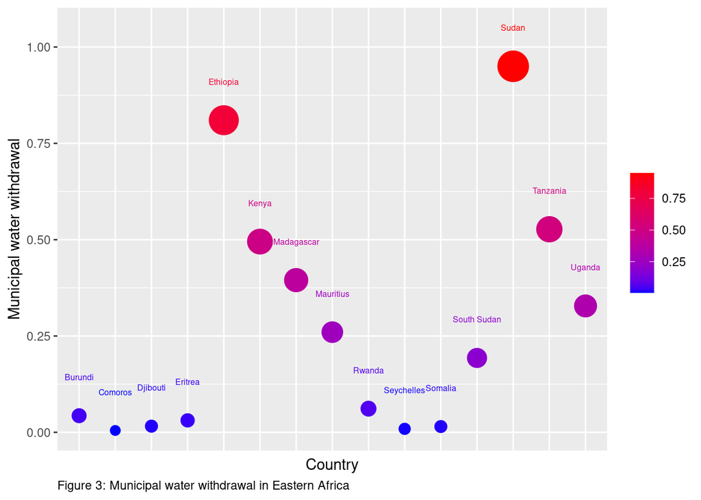

```r
# Create the bubble chart with country names and color coding for Municipal withdrawal (Figure 3)
ggplot(subset_data, aes(x = Country, y = munic_withd, size = munic_withd, color = munic_withd)) +
  geom_point() +
  geom_text(aes(label = Country), nudge_y = 0.1, size = 2.1) + # Add country names over bubbles
  scale_size_continuous(range = c(3, 10), guide = "none") + # Remove size legend
  scale_color_gradient(low = "blue", high = "red") + # Color gradient based on values
  labs(x = "Country",
       y = "Municipal water withdrawal",
       color = NULL, # Remove color legend title
       size = NULL,
       caption = paste0("Figure 3: Municipal water withdrawal in Eastern Africa")) + # Add figure label
  theme(axis.text.x = element_blank(), # Remove X-axis text
        axis.ticks.x = element_blank(), # Remove X-axis ticks
        plot.caption = element_text(hjust = 0)) # Align caption to the left
```

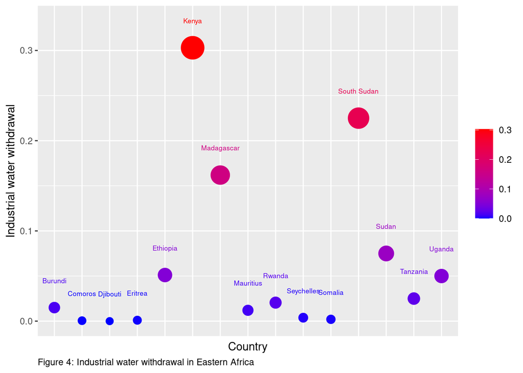

```r
# Create the bubble chart with country names and color coding for Industrial withdrwal (Figure 4)
ggplot(subset_data, aes(x = Country, y = ind_withd, size = ind_withd, color = ind_withd)) +
  geom_point() +
  geom_text(aes(label = Country), nudge_y = 0.03, size = 2.3) + # Add country names over bubbles
  scale_size_continuous(range = c(3, 10), guide = "none") + # Remove size legend
  scale_color_gradient(low = "blue", high = "red") + # Color gradient based on values
  labs(x = "Country",
       y = "Industrial water withdrawal",
       color = NULL, # Remove color legend title
       size = NULL,
       caption = paste0("Figure 4: Industrial water withdrawal in Eastern Africa")) + # Add figure label
  theme(axis.text.x = element_blank(), # Remove X-axis text
        axis.ticks.x = element_blank(), # Remove X-axis ticks
        plot.caption = element_text(hjust = 0)) # Align caption to the left
```

```r
# Printing Table 2; Access to safe drinking water in Eatern Africa
# Selecting specific columns
water_access <- data_water_subset[c("Country", "pop_safe_wat", "rural_pop_safe_wat", "urban_pop_safe_wat")]

# Renaming the columns
colnames(water_access) <- c("Country", "Total", "Rural", "Urban")

# Omitting rows with NA values
water_access <- na.omit(water_access)

# Rounding the values to one decimal place
water_access[, 2:4] <- lapply(water_access[, 2:4], function(x) round(as.numeric(x), 1))

knitr::kable(water_access, "html") %>%
  kableExtra::add_header_above(c("Table 2: Access (population percent) to safe drinking water in Eastern Africa (2015)" = 4)) %>%
  kableExtra::kable_styling(bootstrap_options = c("striped", "hover"), full_width = FALSE, latex_options = "label = tab:water_resources") %>%
  kableExtra::column_spec(seq_len(ncol(subset)), width = c(80, 100, 150, 150))
```

| Table 2: Access (population percent) to safe drinking water in Eastern Africa (2015) Country | Table 2: Access (population percent) to safe drinking water in Eastern Africa (2015) Total | Table 2: Access (population percent) to safe drinking water in Eastern Africa (2015) Rural | Table 2: Access (population percent) to safe drinking water in Eastern Africa (2015) Urban |
| --- | --- | --- | --- |
| Burundi | 75.9 | 73.8 | 91.1 |
| Comoros | 90.1 | 89.1 | 92.6 |
| Djibouti | 90.0 | 64.7 | 97.4 |
| Eritrea | 57.8 | 53.3 | 73.2 |
| Ethiopia | 57.3 | 48.6 | 93.1 |
| Kenya | 63.2 | 56.8 | 81.6 |
| Madagascar | 51.5 | 35.3 | 81.6 |
| Mauritius | 99.9 | 99.8 | 99.9 |
| Rwanda | 76.1 | 71.9 | 86.6 |
| Seychelles | 95.7 | 95.7 | 95.7 |
| Somalia | NA | NA | NA |
| South Sudan | 58.7 | 56.9 | 66.7 |
| Sudan | 55.5 | 50.2 | 66.0 |
| Uganda | 79.0 | 75.8 | 95.5 |
| Tanzania | 55.6 | 45.5 | 77.2 |

# Conclusion

- The Eastern Africa region has limited water resources representing about 6.5% of Africa’s internal resources.
- Water resource distribution within the region varies significantly with four aridity zones including moist sub-humid, dry sub-humid, semi-arid, and arid.
- The western part of Eastern Africa has surplus rainfall, while the northern areas have large water deficits.

# Acknowledgement

This work was developed following the successful completion of the data science for [open wash data](https://ds4owd-001.github.io/website/) course. The author is grateful to [Lars Schöbitz](https://openwashdata.org/about/lars/) of the Global Health Engineering group at ETH Zurich for the training.

## References

Gunda, Thushara, David Hess, George M. Hornberger, and Scott Worland. 2019. “Water Security in Practice: The Quantity-Quality-Society Nexus.” *Water Security* 6 (March): 100022. https://doi.org/10.1016/J.WASEC.2018.100022.

Haile, Gebremedhin Gebremeskel, Qiuhong Tang, Seyed Mohammad Hosseini-Moghari, Xingcai Liu, T. G. Gebremicael, Guoyong Leng, Asfaw Kebede, Ximeng Xu, and Xiaobo Yun. 2020. “Projected Impacts of Climate Change on Drought Patterns over East Africa.” *Earth’s Future* 8: 1–23. https://doi.org/10.1029/2020EF001502.

Mapani, Benjamin, Hodson Makurira, Lapologang Magole, Maideyi Meck, Theresa Mkandawire, Marloes Mul, and Cosmo Ngongondo. 2019. “Integrated Water Resources Development and Management:innovative Technological Advances for Water Security in Eastern and Southern Africa.” *Physics and Chemistry of the Earth* 112: 1–2. https://doi.org/10.1016/j.pce.2019.08.004.

Mutschinski, Kristin, and Neil A. Coles. 2021. “The African Water Vision 2025: Its Influence on Water Governance in the Development of Africa s Water Sector, with an Emphasis on Rural Communities in Kenya: A Review.” *Water Policy*. IWA Publishing. https://doi.org/10.2166/wp.2021.032.

Sherry, Julia, Luke Juran, Korine N. Kolivras, Leigh Anne H. Krometis, and Erin J. Ling. 2019. “Perceptions of Water Services and Innovations to Improve Water Services in Tanzania.” *Public Works Management and Policy* 24: 260–83. https://doi.org/10.1177/1087724X18815486.